# ChatGPT as an Exogenous Shock

Media Coverage of AI’s Labour-Market Implications in Croatia, 2021–2026

Authors

Affiliations

Petra Palić

Croatian Catholic University

Luka Šikić

Croatian Catholic University

Antea Barišić

University of Zagreb

Published

September 29, 2026

# 1 Abstract

ChatGPT’s November 30, 2022 release made generative artificial intelligence visible to a mass audience overnight. We treat the launch as an exogenous shock and trace its effect on Croatian digital media coverage of AI and the labour market, using 134,751 Croatian-language items published between January 2021 and August 2026 and drawn from the Determ media-monitoring database. Coverage did not jump at the launch; it accelerated. Monthly volume shows no significant level shift in December 2022 but a sustained increase in its trend (92.8 additional items per month, each month), rising from 725 items a month before the launch to 2,624 after it, and a December 2021 placebo is null. The share of items carrying a threat frame (job loss, fear, inequality) rose from 16.5% to 23.0%, while the opportunity share (job creation, productivity, transformation) stayed flat; fear-and-resistance framing continued to grow for more than three years, and skills and reskilling framing fell and did not recover. Contrary to our prediction, quality outlets increased threat framing more than tabloids. Threat-framed articles attract more reader interactions than other articles, consistent with a demand-side explanation of the shift.

# 2 Introduction

Croatian-language digital coverage of AI and work grew from about 725 items a month before ChatGPT’s release to 2,624 a month afterwards, and by 2026 it averaged 4,616 items a month. Its tone changed with its volume: the share of items framing AI as a threat to jobs, as a source of fear, or as a driver of inequality rose from 16.5% before the launch to 23.0% after it. Whether generative AI ultimately displaces, complements, or transforms human work remains an open empirical question (Acemoglu and Restrepo 2018; Autor 2015; Bessen 2019). Workers, firms, and policymakers must nonetheless act under uncertainty, and the public information environment that shapes those actions has moved measurably.

Task-level evidence suggests that large language models are exposed to a wide and disproportionately white-collar share of occupations (Eloundou et al. 2023; Felten et al. 2021), and field experiments find that generative AI raises productivity for some workers (Brynjolfsson et al. 2023). In a small economy such as Croatia, where firm-level data on AI adoption are sparse, the main channel through which workers and policymakers learn about these capabilities is mediated coverage. Which frames that channel transmits, how quickly, and how persistently is therefore an input to belief formation and labour-market adjustment.

This paper estimates how the November 30, 2022 ChatGPT release changed Croatian digital media coverage of AI and the labour market. We treat the release as an exogenous shock to the salience of generative-AI capabilities and follow coverage for 23 months before and 45 months after it. The corpus of 134,751 items is drawn from the Determ media-monitoring database through a two-stage filter that requires both an AI term and a labour-market term. We combine an interrupted time series for volume, structural-break tests that locate breaks without imposing the launch date, frame-level event studies, and a tabloid–quality difference-in-differences.

Four findings stand out. First, the launch changed the *trajectory* of coverage rather than its level. Monthly volume shows no significant jump in December 2022 (15.4 items, p = 0.95) but its trend increases by 92.8 items per month, each month, after the launch. The Bai–Perron procedure dates the first break to Feb 2023 (95% interval Jan 2023–Apr 2023), within three months of the launch, and a second to Jun 2024; a placebo at December 2021 is null.

Second, the tone of coverage shifted toward threat. The threat share rose from 16.5% to 23.0% while the opportunity share barely moved (30.0% to 29.8%). The shift was gradual rather than abrupt: within 24 months of the launch the threat share is 5.7 percentage points higher than its trend would predict (p = 0.02), but over the full sample a linear trend absorbs most of the change. Fear-and-resistance framing drives the shift, rising by 3.8 points in the first six months and by 8.2 points from December 2024 onward, while skills and reskilling framing fell by 2.5 points and stayed down.

Third, the prediction that tabloids would amplify threat framing most is rejected. Quality outlets, which started from a lower threat share, increased it by more than tabloids did; the difference-in-differences estimate is -7.0 percentage points for tabloids relative to quality outlets (p = 0.038 with two-way clustering; 0.087 with a wild-cluster bootstrap).

Fourth, readers reward threat framing. Among web articles from the same outlet in the same month, threat-framed articles receive 10.4% more interactions and opportunity-framed articles 5.8% fewer, which is consistent with editors responding to demand.

The paper contributes to three literatures. For work on automation expectations (Acemoglu and Restrepo 2018; Autor 2022), it documents the supply of public information that shapes those expectations in a small European economy where direct measurement of AI adoption is not available. For work on media framing of AI (Fast and Horvitz 2017; Chuan et al. 2019; Nguyen and Hekman 2024), most of it descriptive and on English-language media, it provides event-study evidence around a dated shock, a post-period of almost four years, and direct evidence on outlet type and reader demand. For work on the labour-market consequences of generative AI (Eloundou et al. 2023; Felten et al. 2021; Brynjolfsson et al. 2023), it supplies a measurable input, the tone of coverage, that can be linked to vacancy, employment, and reskilling outcomes.

Section 3 describes the Croatian media market and the conceptual framework. Section 4 describes the corpus, the frame dictionaries, and the outlet classification. Section 5 sets out the empirical strategy. Section 6 reports the results, Section 7 the robustness checks, and Sections 8 and 9 discuss and conclude.

# 3 Institutional and Conceptual Background

## 3.1 The Croatian Media Landscape

Croatia’s online news market is served by a small number of national portals, most of which belong to a handful of domestic and foreign owners. Styria Media Group, an Austrian company, owns the tabloid *24sata*, which Peruško (2024) describes as the best-selling newspaper and one that attracts large numbers of readers online, as well as *Večernji list* and *Poslovni dnevnik*. The domestically owned Hanza Media, the print market leader, publishes *Jutarnji list* and *Slobodna Dalmacija*. United Group operates Nova TV, whose news portal is *Dnevnik.hr*, and the cable news channel N1, while the Czech-based CME has owned RTL Hrvatska since 2022 (Peruško 2024). RTL Hrvatska took over the portal *Net.hr* from Telegram Media Grupa in 2021 (Net.hr 2021), which continues to publish *Telegram*. *Index.hr* is independently owned, and *Tportal* is published by Hrvatski Telekom.

The outlets we analyse by name are listed, with their owners and their number of items in our corpus, in Table 2 (Section 4.3). They are the national portals of these groups plus the public broadcaster, two regional dailies, and specialist technology and business titles. Items from all other sources enter the aggregate analysis but not the outlet-level comparisons.

The outlet typology used throughout the paper (Tabloid, Quality, Regional, Public, Tech, Business) describes editorial model and audience rather than ownership: an owner group can publish both a tabloid and a quality title, as Styria does with *24sata* and *Večernji list*. Tabloid outlets (24sata, Index.hr, Net.hr) prioritise high-volume, attention-driven coverage; quality outlets (Jutarnji list, Večernji list, Dnevnik.hr, N1, Telegram, Tportal) run longer analytical pieces. The Tabloid–Quality contrast is the basis for the difference-in-differences in Section 6.8.

## 3.2 ChatGPT as a Salience Shock

We treat ChatGPT’s November 30, 2022 public release as an unanticipated shock to the salience of generative-AI capabilities for Croatian editors and readers. The release was announced and shipped on the same day. Section 5.3 reports the in-corpus evidence: only 4 items in our corpus mention ChatGPT before the release, and the pre-launch items that mention OpenAI or GPT concern earlier models.

The treatment date is December 1, 2022, the first month in which every day is post-release in the monthly aggregation our design uses.

## 3.3 Conceptual Framework

A short verbal model of editorial choice under attention scarcity yields three predictions. Editors fill a limited number of article slots to maximise expected readership, and readers respond more strongly to a vivid downside than to a measured upside (Soroka and McAdams 2015; Robertson et al. 2023). A salience shock expands the menu of story angles and raises the expected return to AI-and-work coverage relative to other topics competing for the same slots.

Three predictions follow. First, coverage volume rises after the shock, because the expected return to the topic now exceeds the opportunity cost of a slot (tested in Sections 6.1–6.2). Second, threat-leaning angles (displacement, fear, inequality) gain more than opportunity-leaning angles (job creation, productivity, transformation), because reader negativity bias makes threat angles more profitable per slot (Sections 6.3–6.6). Third, outlets whose business model depends most on attention-driven revenue, tabloids, amplify the threat tilt more than quality outlets that depend more on subscriptions and reputation (Esser 1999) (Section 6.8). The demand-side mechanism behind the second prediction also implies that threat-framed articles attract more reader engagement, which we test in Section 6.9.

### 3.3.1 Literature review (draft outline for the co-authors)

1. **Framing as selection and salience.** Entman (1993) defines framing as selecting some aspects of a perceived reality and making them more salient; Scheufele (1999) separates media frames (what we measure) from audience frames (what we do not); Vreese (2005) distinguishes generic from issue-specific frames. *Where we fit:* our eight frames are issue-specific frames for AI and work, measured as media frames only.
2. **Generic news frames.** Semetko and Valkenburg (2000) identify conflict, human-interest, economic-consequences, responsibility and morality frames. *Where we fit:* map our frames onto these (Section 4.2).
3. **Media framing of AI.** Long-run trends in US press coverage (Fast and Horvitz 2017); benefit and risk framing in US newspapers (Chuan et al. 2019); ethical issues in AI coverage (Ouchchy et al. 2020); how news discourse makes sense of automation (Nguyen and Hekman 2024); ChatGPT headlines in UK media (Roe and Perkins 2023). *Where we fit:* this work is mostly descriptive and on English-language media; we give event-study evidence around a dated shock for a small non-English market, with almost four years of post-shock data.
4. **Negativity and the demand for threat framing.** Soroka and McAdams (2015), Soroka et al. (2019) and Robertson et al. (2023) on negativity bias in news attention and consumption; Mullainathan and Shleifer (2005) and Gentzkow and Shapiro (2010) on demand-driven media content. *Where we fit:* motivates prediction 2 and the engagement test in Section 6.9.
5. **Tabloidisation and outlet type.** Esser (1999). *Where we fit:* motivates prediction 3, which our data reject; the write-up should discuss why quality outlets responded more (Section 8).
6. **Labour-market exposure to generative AI.** Eloundou et al. (2023), Felten et al. (2021), Brynjolfsson et al. (2023): the benchmark against which the tone of coverage can be judged.

# 4 Data and Measurement

## 4.1 Corpus Construction

The corpus draws on the Determ media-monitoring database, which holds about 42 million records of Croatian-language digital content published between January 2021 and September 2026. Each record is one published item: a news-portal article, a Facebook post, a tweet, a YouTube video description, a Reddit post, a forum post, or an item from another monitored channel. We use every month from January 2021 to August 2026, the last complete month, and exclude reader comments on news sites, which are audience reactions rather than media content.

We construct the analytical corpus through a two-stage intersection filter. An item enters the corpus only if its title or full text contains at least one term from an AI-and-technology vocabulary *and* at least one term from a labour-market vocabulary. The first vocabulary covers terms such as *umjetna inteligencija* (artificial intelligence), *strojno učenje* (machine learning), ChatGPT, GPT, OpenAI, *automatizacija*, *robotizacija*, *algoritam*, *neuronska mreža*, *chatbot*, and related expressions. The second covers labour-market terms including *posao* (job), *zaposlen* (employed), *nezaposlenost* (unemployment), *radno mjesto* (workplace), *tržište rada* (labour market), *vještine* (skills), *karijera* (career), *produktivnost* (productivity), *otpuštanje* (lay-offs), *prekvalifikacija* (reskilling), and *plaća* (wage). A fast SQL pre-filter selects candidates in the database; stem-based regular expressions, which accommodate Croatian inflection (the pattern `umjetn.*inteligencij` matches all case forms of *umjetna inteligencija*), then confirm both conditions. After removing duplicates on title, date, and source, the corpus contains 134,751 items.

The corpus records media supply rather than media consumption: we observe what was published, not whether readers saw it or were influenced by it. We treat it as a measure of the public information environment on the supply side throughout.

**Platforms.** Table 1 shows the corpus by platform. Web portals supply 82.8% of all items, so the aggregate results are, in substance, results about news portals. Social-media items come from outlet and public pages, channels and accounts. Forum items come mainly from the Forum.hr discussion board (61.8% of forum items), followed by the Bug.hr forum and regional boards such as Osijek031. Some platforms enter the database only after the launch; they appear in the descriptive tables but cannot contribute to a pre/post comparison.

Table 1: Corpus items by platform

| Platform | Pre-launch | Post-launch | Total | Share (%) | First item |
| --- | --- | --- | --- | --- | --- |
| web | 15,959 | 95,598 | 111,557 | 82.8 | Jan 2021 |
| print | 0 | 6,295 | 6,295 | 4.7 | Jul 2024 |
| radio | 0 | 4,028 | 4,028 | 3.0 | Dec 2024 |
| facebook | 300 | 3,523 | 3,823 | 2.8 | Jan 2021 |
| tv | 0 | 2,880 | 2,880 | 2.1 | Aug 2024 |
| youtube | 167 | 2,532 | 2,699 | 2.0 | Apr 2021 |
| reddit | 88 | 2,181 | 2,269 | 1.7 | May 2021 |
| forum | 143 | 546 | 689 | 0.5 | Aug 2021 |
| instagram | 0 | 372 | 372 | 0.3 | Jan 2024 |
| twitter | 28 | 88 | 116 | 0.1 | Feb 2021 |
| tiktok | 0 | 18 | 18 | 0.0 | Apr 2024 |
| bluesky | 0 | 5 | 5 | 0.0 | Feb 2026 |

Note: Pre-launch: January 2021 to November 2022; post-launch: December 2022 to August 2026. Reader comments are excluded. First item is the month of the platform's first item in the corpus.

**Duplicates across platforms.** An outlet can publish a story on its portal and share it on its Facebook page, so the same story can enter the corpus twice. We measure this directly: 20 of 3,823 Facebook posts (0.5%) repeat the headline of a web item published within two days. Duplication is therefore negligible, and all outlet-level analyses use web items only.

## 4.2 Frame Detection

We operationalise eight interpretive frames, each a distinct way in which the media discuss the relationship between AI and work. Curated Croatian keyword dictionaries detect each frame; an item carries a frame if any of its dictionary terms appears in the title or text. The threat-leaning frames are *job loss* (*gubitak posla*, *ukidanje radnih mjesta*, *zamjena radnika*, *otpuštanje*, *tehnološka nezaposlenost*), *fear and resistance* (*strah od AI*, *prijetnja*, *opasnost*, *neizvjesnost*, *panika*), and *inequality* (*nejednakost*, *digitalni jaz*, *polarizacija*, *nestanak srednje klase*). The opportunity-leaning frames are *job creation* (*nova radna mjesta*, *potražnja za stručnjacima*, *nova zanimanja*), *productivity* (*učinkovitost*, *ušteda*, *gospodarski rast*, *optimizacija*), and *task transformation* (*transformacija rada*, *prilagodba*, *suradnja čovjeka i*, *evolucija poslova*). The remaining two are *skills* (*prekvalifikacija*, *cjeloživotno učenje*, *digitalne vještine*, *reskilling*) and *regulation* (*regulacija AI*, *AI Act*, *zaštita radnika*, *prava radnika*, *sindikat*). Appendix A lists the full dictionaries.

Frames are not mutually exclusive: an item that discusses both displacement and reskilling carries both. We analyse each frame’s monthly prevalence, the share of items carrying it. The dictionaries are not validated against a human-coded sample, so per-frame precision and recall are unknown. Measurement error that is unrelated to the launch date attenuates estimated effects rather than creating them. It does not, however, protect against dictionary terms whose everyday use changes over time, and several fear-and-resistance terms (*prijetnja*, *opasnost*, *upozorenje*) are common outside the AI context. We return to this in the robustness section.

## 4.3 Outlet Classification

The outlet classification is our own; it is not an official or vendor-supplied typology. We assign web items to named outlets by their web domain, using an explicit list in the project configuration file (a domain matches its subdomains, so *sportske.jutarnji.hr* belongs to Jutarnji list). Each outlet is then assigned a type according to its editorial model, and its owner according to Peruško (2024). Only web items are classified, so an outlet’s Facebook page never enters the outlet comparisons. Web items from all other domains form the *Other web* category. Table 2 lists the named outlets.

Table 2: Named outlets in the corpus

| Type | Outlet | Owner | Pre-launch | Post-launch | Total | Share of corpus (%) |
| --- | --- | --- | --- | --- | --- | --- |
| Tabloid | Index.hr | Index Promocija | 323 | 2,669 | 2,992 | 2.2 |
| Tabloid | 24sata | Styria Media Group | 289 | 1,797 | 2,086 | 1.5 |
| Tabloid | Net.hr | RTL Hrvatska (CME) | 34 | 1,376 | 1,410 | 1.0 |
| Quality | Tportal | Hrvatski Telekom | 505 | 3,731 | 4,236 | 3.1 |
| Quality | Dnevnik.hr | United Group | 358 | 3,710 | 4,068 | 3.0 |
| Quality | Jutarnji list | Hanza Media | 774 | 2,414 | 3,188 | 2.4 |
| Quality | Večernji list | Styria Media Group | 529 | 2,447 | 2,976 | 2.2 |
| Quality | Telegram | Telegram Media Grupa | 153 | 995 | 1,148 | 0.9 |
| Quality | N1 Hrvatska | United Group | 10 | 795 | 805 | 0.6 |
| Regional | Novi list | Novi list d.d. | 228 | 1,625 | 1,853 | 1.4 |
| Regional | Slobodna Dalmacija | Hanza Media | 308 | 1,110 | 1,418 | 1.1 |
| Public | HRT | HRT (public broadcaster) | 110 | 943 | 1,053 | 0.8 |
| Tech | Bug | Bug d.o.o. | 383 | 2,536 | 2,919 | 2.2 |
| Tech | Netokracija | Infobip | 223 | 522 | 745 | 0.6 |
| Business | Poslovni dnevnik | Styria Media Group | 443 | 3,397 | 3,840 | 2.8 |
| Business | Lider | Lider media | 558 | 2,140 | 2,698 | 2.0 |

Note: Web items only, matched by domain. Owners follow Peruško (2024) and, for Net.hr, the 2021 takeover by RTL Hrvatska. Together the named outlets account for 27.8% of all corpus items.

## 4.4 Descriptive Summary

Table 3 summarises the corpus, and Table 4 breaks it down by outlet type, aggregating the outlet-level statistics in Appendix E. The named outlets supply 27.8% of all items; most items come from other web portals, among them technology and business sites. In every outlet type the threat share is higher after the launch than before it, while the opportunity share rises in some types and falls in others. Section 6.8 tests these differences formally.

Table 3: Corpus descriptive statistics

| Metric | Value |
| --- | --- |
| Items | 134,751 |
| Distinct sources | 5,468 |
| Period | January 2021 to August 2026 |
| Months (pre / post launch) | 23 / 45 |
| Mean word count | 1,012 |
| Median word count | 656 |
| Items before the launch | 16,685 |
| Items from the launch onward | 118,066 |

Note: The launch month is December 2022. Items are deduplicated on title, date and source.

Table 4: Items and frame shares by outlet type

| Type | Items | Threat pre (%) | Threat post (%) | Opportunity pre (%) | Opportunity post (%) |
| --- | --- | --- | --- | --- | --- |
| Tabloid | 6,488 | 22.1 | 25.6 | 29.1 | 21.8 |
| Quality | 16,421 | 18.4 | 29.1 | 29.7 | 27.6 |
| Regional | 3,271 | 18.3 | 23.9 | 23.9 | 23.3 |
| Public | 1,053 | 12.7 | 21.8 | 21.8 | 21.8 |
| Tech | 3,664 | 14.4 | 20.1 | 24.4 | 32.1 |
| Business | 6,538 | 18.9 | 27.2 | 43.3 | 44.4 |
| Other web | 74,122 | 16.3 | 21.7 | 31.1 | 32.7 |
| Non-web | 23,194 | 3.9 | 26.9 | 12.3 | 25.3 |

Note: Shares of items carrying at least one threat frame (job loss, fear/resistance, inequality) or opportunity frame (job creation, productivity, transformation). Tabloid to Business: the named web outlets. Other web: all other web domains. Non-web: all other platforms.

# 5 Empirical Strategy

## 5.1 Event Definition and Identification

The treatment date is December 1, 2022, the first full month after ChatGPT’s public release. The identifying assumption is that Croatian media did not anticipate the release, so a sharp change in coverage at that date can be attributed to the shock rather than to a smooth pre-existing trend.

The sample runs for 23 months before the launch and 45 months after it. The long post-period is what allows us to ask whether the shift persisted, but it also contains later events that plausibly moved coverage of AI and work: the release of GPT-4 (March 2023), the European Parliament’s adoption of the EU AI Act (March 2024), and the Act’s entry into force (August 2024). We mark these as secondary events in the figures. They do not enter the estimation as separate treatments, so the post-launch coefficients measure the level of coverage after December 2022 relative to before, not the effect of the release alone. For a cleaner estimate of the launch effect we report narrow symmetric windows around the launch in the robustness section.

## 5.2 Specification

For each frame $f$ we estimate an event study on the monthly frame share, with event time grouped into three-month bins:

$$Y_{ft} = \alpha_f + \sum_{b \neq -1} \beta_b^f \cdot \mathbf{1}[\lfloor (t - t^*)/3 \rfloor = b] + \varepsilon_{ft}$$

where $Y_{ft}$ is the share of items carrying frame $f$ in month $t$, $t^*$ is December 2022, and bin $b = -1$ (September–November 2022) is the reference. The coefficient $\beta_b^f$ is the change in frame prevalence in bin $b$ relative to the three months before the launch. We use bins rather than single months because a monthly specification with one dummy per month leaves no degrees of freedom for anything else in a series with one observation per month.

For summary effects we regress each monthly series on a post-launch indicator and a linear time trend, with Newey–West (HAC) standard errors. For aggregate volume we also estimate an interrupted time series (ITS) model (Bernal et al. 2017):

$$N_t = \beta_0 + \beta_1 t + \beta_2 \, \text{Post}_t + \beta_3 \, (t - t^*) \, \text{Post}_t + \varepsilon_t ,$$

where $N_t$ is the monthly item count. Because the slope-change term is measured from the launch month, $\beta_2$ is the jump in volume *at* the launch, and $\beta_3$ is the change in the monthly trend after it.

We complement the ITS with structural-break tests that do not impose the launch date: a Sup-F test over the central 70% of the sample, and the Bai–Perron break-dating procedure. A placebo at December 2021 checks for seasonal artefacts.

## 5.3 Threats to Identification

**Anticipation.** We count pre-launch items that mention ChatGPT or related terms. Although Croatian interest in ChatGPT was minimal before the launch, we find 528 pre-launch items in the corpus that mention OpenAI or GPT (3.16% of pre-launch items). Before the launch these terms referred to earlier models such as GPT-3; only 4 pre-launch items mention ChatGPT itself. Anticipation is therefore not a quantitatively important threat.

**Confounding events.** Croatia adopted the euro and joined the Schengen Area on January 1, 2023, one month after the launch. Neither concerns AI, and the corpus filter requires an AI term, so these events enter the corpus only where an item also discusses AI and work. We re-estimate excluding January 2023. The later AI-specific events (GPT-4, the EU AI Act) are part of the post-launch environment, as discussed above.

**Measurement error in framing.** The dictionaries are not validated against human coding. Error unrelated to the launch date attenuates estimates, but dictionary terms whose general use changes over time can bias them. We re-estimate the threat composite without the fear-and-resistance dictionary, whose terms are the most generic.

**Selection into the corpus.** The corpus includes every item in the monitoring database that passes the filter; the named outlets in Table 2 are the national portals of the main ownership groups, the public broadcaster, and specialist titles, and together they account for 27.8% of the corpus. The database covers smaller regional portals and niche forums less deeply, and it adds platforms over time (Table 1). Because web portals supply almost all items and the outlet-level analyses use web items from a fixed list of outlets, changes in platform coverage cannot drive the outlet comparisons. We also report the headline estimates on web items only.

## 5.4 Inference

Monthly time-series regressions use Newey–West (HAC) standard errors. The article-level difference-in-differences in Section 6.8 clusters on outlet and year-month. Because the Tabloid and Quality groups together contain only 9 outlets, we also report a wild-cluster bootstrap p-value (restricted, Webb weights, 9,999 draws, clustered on outlet), following Cameron et al. (2008) and MacKinnon and Webb (2017); where it disagrees with the asymptotic p-value, we follow the bootstrap. All outlets are treated on the same date, so the staggered-adoption critiques of two-way fixed effects (Goodman-Bacon 2021; Chaisemartin and D’Haultfœuille 2020) do not apply.

# 6 Results

## 6.1 Volume Shock

Figure 1 plots the monthly number of corpus items with the fitted interrupted-time-series line. From January 2021 to November 2022 volume averages 725 items a month and drifts slightly downward. From December 2022 onward it averages 2,624 items a month, a 3.6-fold increase, and it keeps rising: from 764 items a month in 2021 to 4,616 in 2026.

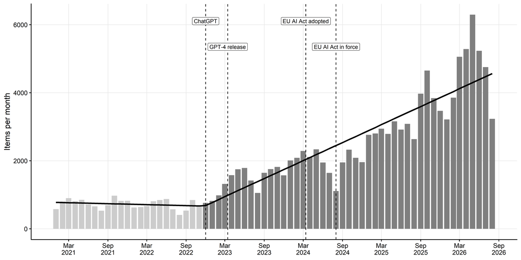

Figure 1: Monthly item volume and interrupted-time-series fit

**Note:** Bars show the number of corpus items per month (light grey before the launch, dark grey from December 2022). The black line is the fit of the interrupted-time-series model in Table 5. Dashed lines mark the ChatGPT launch and the secondary events: the GPT-4 release (March 2023), the European Parliament’s adoption of the EU AI Act (March 2024), and the Act’s entry into force (August 2024).

Table 5 reports the ITS estimates. The level shift, the jump in monthly volume at December 2022, is 15.4 items and is not statistically different from zero (p = 0.95). The launch instead changed the slope: after December 2022 monthly volume grows by an additional 92.8 items per month (HAC SE 10.6), against a pre-launch trend of -4.7 items per month. ChatGPT therefore did not produce a one-off burst of coverage followed by a return to the old level. It set coverage on a new, steeper path.

Table 5: Interrupted time series for monthly item volume

| Term | Estimate | SE | t | p |
| --- | --- | --- | --- | --- |
| Intercept (level in January 2021) | 777.12 | 13.95 | 55.69 | < 0.001 |
| Pre-launch trend (items per month) | -4.70 | 1.50 | -3.14 | 0.003 |
| Level shift at December 2022 | 15.36 | 229.96 | 0.07 | 0.947 |
| Change in trend after the launch | 92.85 | 10.56 | 8.79 | < 0.001 |

Note: Dependent variable: items per month. Model: N = b0 + b1 t + b2 Post + b3 (t - t*) Post, where t counts months from January 2021 and t* is December 2022. Because the trend-change term is measured from the launch month, b2 is the jump at the launch. Newey-West (HAC) standard errors. N = 68 months.

Table 6 reports the incidence-rate ratio for the post-launch period under four count specifications. Without a trend, post-launch volume is 3.62 times its pre-launch level. Once a linear trend is included the ratio falls to 1.09 (p = 0.48), because a single trend fitted to the whole period absorbs the post-launch acceleration. Within outlets (column 4), volume after the launch is 2.38 times its pre-launch level.

Table 6: Post-launch volume under four count specifications

|  | (1) Post only | (2) + Trend | (3) + Month FE | (4) Source panel |
| --- | --- | --- | --- | --- |
| Post (coefficient) | 1.286 | 0.085 | 0.065 | 0.869 |
| Post (SE) | (0.175) | (0.118) | (0.091) | (0.063) |
| Post (IRR) | 3.62 | 1.09 | 1.07 | 2.38 |
| Linear trend | No | Yes | Yes | No |
| Month-of-year FE | No | No | Yes | Yes |
| Source FE | No | No | No | Yes |
| Observations | 68 | 68 | 68 | 25,936 |

Note: Dependent variable: items per month (columns 1-3) or items per source and month (column 4). Columns 1-3: quasi-Poisson, standard errors from the quasi-likelihood. Column 4: Poisson with source and month-of-year fixed effects, standard errors clustered by source. IRR = exp(coefficient).

## 6.2 Structural Break Tests

The ITS imposes the launch date. The Sup-F test and the Bai–Perron procedure do not: they search for breaks in the relationship between monthly volume and time over the central 70% of the sample. Table 7 reports the results, and Figure 2 the OLS-CUSUM path.

Table 7: Structural-break tests for monthly item volume

| Statistic | Value |
| --- | --- |
| Sup-F statistic | 52.8 |
| Sup-F p-value | < 0.001 |
| Sup-F break date (levels) | Jun 2024 |
| Sup-F break date (log volume) | Jan 2023 |
| Bai-Perron break 1 (95% CI) | Feb 2023 (Jan 2023 – Apr 2023) |
| Bai-Perron break 2 (95% CI) | Jun 2024 (Sep 2023 – Jul 2024) |

Note: Model: items per month on a constant and a linear trend. The Sup-F test searches the central 70% of the sample for a single break; the Bai-Perron procedure chooses the number of breaks by BIC (minimum segment 15% of the sample) and reports 95% confidence intervals for the dates. The launch month is December 2022.

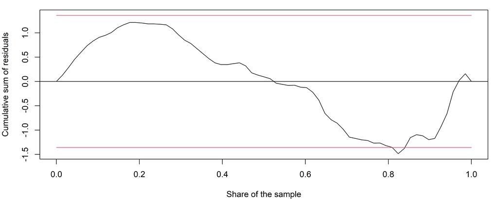

Figure 2: OLS-CUSUM test for the monthly volume series

The Sup-F test rejects parameter stability (p < 0.001). The first break chosen by the Bai–Perron procedure falls in Feb 2023, with a 95% confidence interval from Jan 2023 to Apr 2023, within three months of the launch. On the log scale the single most pronounced break is in Jan 2023. The second Bai–Perron break, in Jun 2024 (Sep 2023–Jul 2024), is the date the Sup-F test picks on the level series, where the growth of 2024–2026 dominates. It marks a further acceleration during the months in which the EU AI Act was adopted and entered into force, which our design does not separate from other developments in 2024. The volume data therefore show two regime changes, the first of which coincides with the ChatGPT launch.

## 6.3 Event-Study Coefficients

Figure 3 shows the event-study coefficients for each frame: the change in the frame’s monthly share, in three-month bins, relative to the three months before the launch.

[figure not shown]

Figure 3: Event-study coefficients by frame

**Note:** Coefficients from a regression of the monthly share of items carrying each frame on three-month event-time bins; the reference bin is September–November 2022. Points are placed at the first month of each bin; the dotted line marks December 2022. Bands are 95% confidence intervals from Newey–West (HAC) standard errors. Appendix B reports the coefficients.

The frames move in different directions and on different time profiles. Fear and resistance rises most: by 3.8 percentage points in the first six months after the launch and by 8.2 points on average from December 2024 onward, so the shift grew rather than faded. Skills and reskilling falls by around four points immediately and stays there (-4.0 points from December 2024). Productivity falls in the first half-year (-3.2 points) and then recovers above its pre-launch level (2.3 points from December 2024). Regulation rises after the launch and peaks at 4.7 points in the bin starting December 2024, around the EU AI Act’s entry into force and the start of its first obligations. Job loss, job creation, transformation, and inequality move by one to two points at most.

## 6.4 Pre-Trend Validation

A flat pre-launch path is a precondition for reading post-launch movements as responses to the shock. Table 8 reports, for each frame, a joint F-test that the pre-launch bins are equal after allowing for a linear trend, and a separate test of the pre-launch slope.

Table 8: Pre-trend tests by frame

| Frame | F (binned) | F p-value | Slope (pp/month) | Slope p-value |
| --- | --- | --- | --- | --- |
| JOB_LOSS | 0.83 | 0.568 | 0.061 | 0.110 |
| JOB_CREATION | 1.55 | 0.233 | -0.119 | 0.046 |
| TRANSFORMATION | 0.56 | 0.756 | -0.130 | 0.023 |
| SKILLS | 0.63 | 0.704 | 0.009 | 0.843 |
| REGULATION | 1.69 | 0.196 | -0.085 | 0.216 |
| PRODUCTIVITY | 0.71 | 0.651 | -0.143 | 0.140 |
| INEQUALITY | 3.13 | 0.037 | -0.032 | 0.327 |
| FEAR_RESISTANCE | 1.45 | 0.266 | -0.155 | 0.115 |

Note: Sample: pre-launch months (January 2021 to October 2022). F-test: joint null that three-month bin dummies are zero in a regression of the monthly frame share on the bins and a linear trend (reference bin: August-October 2022). Slope: coefficient on a linear trend in a separate regression. Classical OLS standard errors.

Seven of the eight frames pass the binned F-test at the 5% level; the exception is inequality. Two frames, job creation and transformation, have a significant negative pre-launch slope, so their post-launch coefficients, which are measured against the three months before the launch, should be read with that downward drift in mind. The fear-and-resistance frame, which drives the main result, passes both tests.

## 6.5 Average Post-Launch Effects

Table 9 summarises each frame with a single number: the coefficient on a post-launch indicator in a regression of the monthly frame share on the indicator and a linear trend. With almost four post-launch years, this specification is demanding: a linear trend fitted to the whole period absorbs gradual shifts, so it isolates changes in level at the launch rather than cumulative change. The pre- and post-launch means are shown alongside.

Table 9: Average post-launch change in frame shares

| Frame | Pre mean (%) | Post mean (%) | Post coefficient (pp) | SE | p |
| --- | --- | --- | --- | --- | --- |
| PRODUCTIVITY | 24.43 | 25.12 | -3.18 | 2.05 | 0.126 |
| SKILLS | 8.07 | 5.19 | -2.47 | 0.52 | < 0.001 |
| REGULATION | 3.73 | 5.43 | 0.95 | 0.70 | 0.176 |
| JOB_LOSS | 1.41 | 2.46 | 0.79 | 0.57 | 0.168 |
| FEAR_RESISTANCE | 14.31 | 20.27 | 0.75 | 2.17 | 0.729 |
| TRANSFORMATION | 5.00 | 4.79 | 0.32 | 0.74 | 0.666 |
| JOB_CREATION | 4.97 | 4.32 | -0.31 | 0.66 | 0.634 |
| INEQUALITY | 2.09 | 2.33 | 0.10 | 0.38 | 0.789 |

Note: Dependent variable: monthly share of items carrying the frame, in percentage points. Post coefficient: coefficient on a post-launch indicator (December 2022 onward) in a regression with a linear time trend. Newey-West (HAC) standard errors. Frames are ordered by the absolute size of the coefficient.

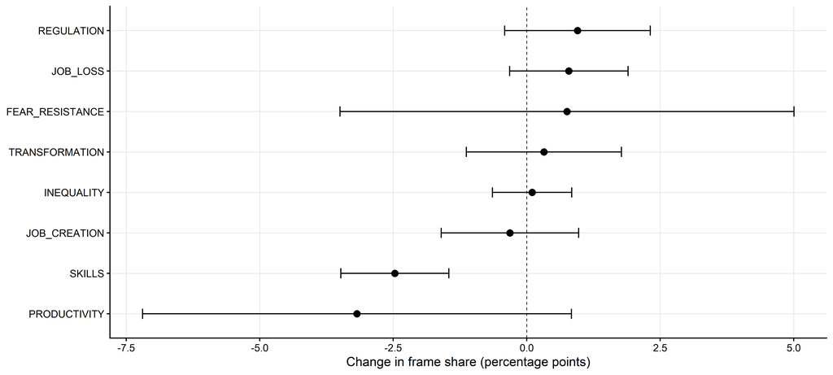

Figure 4: Post-launch coefficients by frame

**Note:** Point estimates and 95% confidence intervals from Table 9.

Only the skills frame changes significantly by this measure: it falls by 2.5 percentage points (p = < 0.001). The raw means tell a fuller story. Fear and resistance rises from 14.3% of items before the launch to 20.3% after it, and job loss from 1.4% to 2.5%. The trend-adjusted coefficients for these frames are small because the increase builds up over the post-launch period rather than arriving at once, as the event study showed.

## 6.6 Threat and Opportunity

The three threat-leaning frames and the three opportunity-leaning frames are combined into two composite indices: the share of items carrying at least one frame of each kind. Figure 5 plots both over time.

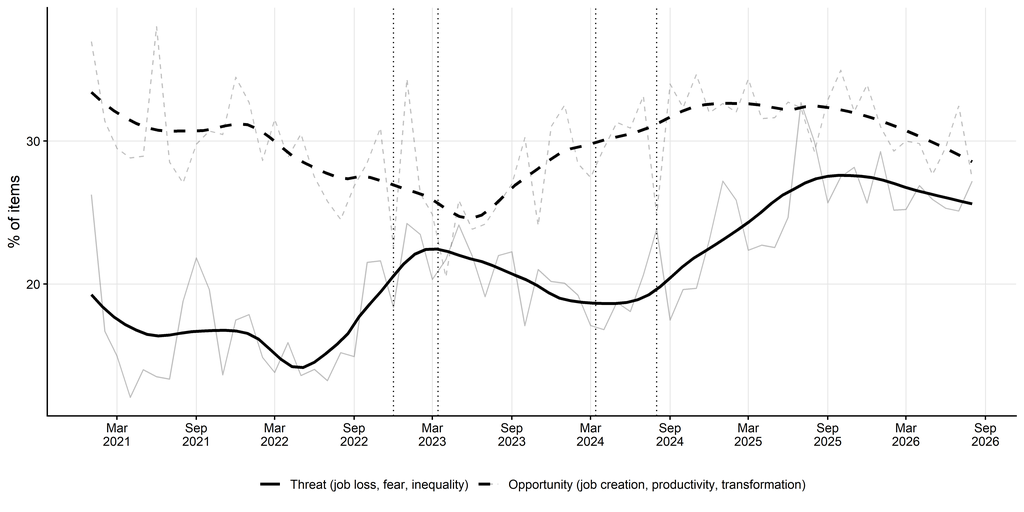

Figure 5: Threat and opportunity indices over time

**Note:** Monthly shares of items carrying at least one threat frame or at least one opportunity frame. Thin lines: monthly values; thick lines: LOESS smooths (span 0.3). Dotted lines mark the ChatGPT launch and the secondary events listed in Figure 1.

Opportunity framing is more common than threat framing throughout the sample, but the distance between them shrinks after the launch. The threat share rises from 16.5% to 23.0% and reaches 26.3% in 2026; the opportunity share moves from 30.0% to 29.8%. The threat–opportunity gap therefore narrows from -13.6 to -6.7 percentage points. The asymmetry the conceptual framework predicts is an asymmetry in *changes*: threat framing gains and opportunity framing does not.

Table 10 reports the trend-adjusted post-launch coefficients for the two indices and for the gap. As with the individual frames, a linear trend fitted to the whole period absorbs much of the gradual shift: the coefficient on the gap is 4.7 points (p = 0.13). Estimated in windows around the launch, which are less exposed to later events, the threat index is 5.9 points higher within 18 months (p = 0.06) and 5.7 points higher within 24 months (p = 0.02); see Table 17.

Table 10: Post-launch change in the threat and opportunity indices

| Index | Pre mean (%) | Post mean (%) | Post coefficient | SE | p | Trend (pp/month) |
| --- | --- | --- | --- | --- | --- | --- |
| Threat | 16.5 | 23.0 | 1.19 | 1.95 | 0.545 | 0.157 |
| Opportunity | 30.0 | 29.8 | -3.52 | 2.33 | 0.136 | 0.095 |
| Gap (threat - opportunity) | -13.6 | -6.7 | 4.71 | 3.09 | 0.132 | 0.062 |

Note: Dependent variable: monthly share of items (percentage points). Post coefficient: coefficient on a post-launch indicator in a regression with a linear time trend. Newey-West (HAC) standard errors.

## 6.7 Platform Heterogeneity

Web portals dominate the corpus (Table 1). Figure 6 shows monthly volume on each platform with at least 100 items.

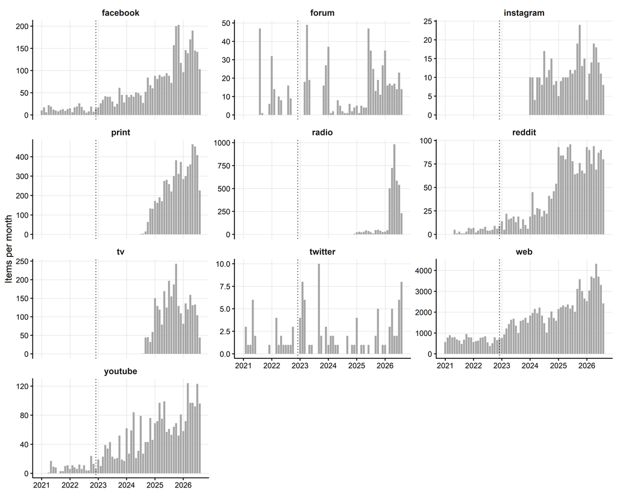

Figure 6: Monthly item volume by platform

**Note:** Items per month on each platform with at least 100 corpus items; vertical scales differ across panels. The dotted line marks December 2022. Instagram, print, radio and television items appear in the database only from 2024.

Table 11 applies the interrupted time series to each platform with at least 30 pre-launch items. On web portals volume both jumps at the launch and accelerates afterwards. On Facebook, YouTube and Reddit the level shift is not significant but the trend increases, as in the aggregate series; forum volume shows neither. Platforms that enter the database only after the launch are listed with their post-launch means but cannot be used for a before–after comparison.

Table 11: Volume by platform before and after the launch

| Platform | Items | Pre (per month) | Post (per month) | Level shift | p (level) | Trend change | p (trend) |
| --- | --- | --- | --- | --- | --- | --- | --- |
| web | 111,557 | 693.9 | 2124.4 | 280.2 | 0.029 | 60.90 | < 0.001 |
| print | 6,295 | 0.0 | 139.9 | — | — | — | — |
| radio | 4,028 | 0.0 | 89.5 | — | — | — | — |
| facebook | 3,823 | 13.0 | 78.3 | -8.4 | 0.407 | 3.38 | < 0.001 |
| tv | 2,880 | 0.0 | 64.0 | — | — | — | — |
| youtube | 2,699 | 7.3 | 56.3 | 2.7 | 0.604 | 1.41 | < 0.001 |
| reddit | 2,269 | 3.8 | 48.5 | -6.4 | 0.276 | 1.85 | < 0.001 |
| forum | 689 | 6.2 | 12.1 | -2.5 | 0.770 | 0.14 | 0.771 |
| instagram | 372 | 0.0 | 8.3 | — | — | — | — |
| twitter | 116 | 1.2 | 2.0 | — | — | — | — |
| tiktok | 18 | 0.0 | 0.4 | — | — | — | — |
| bluesky | 5 | 0.0 | 0.1 | — | — | — | — |

Note: Pre and post: mean items per month before and from December 2022. Level shift and trend change: interrupted-time-series coefficients as in the aggregate model, with Newey-West (HAC) standard errors, estimated only for platforms with at least 30 pre-launch items (—: fewer).

## 6.8 Outlet-Type Heterogeneity

Prediction 3 is that tabloids amplify threat framing more than quality outlets. We test it with a difference-in-differences on web items from the named tabloid and quality outlets, with the item-level threat indicator as the outcome and year-month fixed effects absorbing shocks common to both groups.

Table 12: Difference-in-differences: tabloid versus quality outlets

| Term | Estimate | SE (robust) | SE (two-way cluster) | p (two-way cluster) | p (wild bootstrap) |
| --- | --- | --- | --- | --- | --- |
| Post-launch × Tabloid | -0.0703 | 0.0193 | 0.0283 | 0.038 | 0.087 |
| Tabloid | 0.0349 | 0.0181 | 0.0362 | 0.363 | — |

Note: Dependent variable: 1 if the item carries a threat frame (job loss, fear/resistance or inequality). Sample: web items from the 9 named tabloid and quality outlets (22,909 items). Year-month fixed effects absorb the post-launch main effect. Two-way clustering by outlet and year-month. Wild bootstrap: restricted wild-cluster bootstrap clustered by outlet, Webb weights, 9,999 draws. Reclassifying N1 as a tabloid gives an interaction of -0.0738 (p = 0.040).

The interaction is negative: after the launch, tabloids increased threat framing by 7 percentage points *less* than quality outlets (two-way clustered p = 0.038; wild-cluster bootstrap p = 0.087). The raw shares show why. Tabloids started from a higher threat share (22.1%) and rose modestly to 25.6%, while quality outlets rose from 18.4% to 29.1%. Prediction 3 is rejected: the threat shift is not a tabloid phenomenon, and it is strongest in the quality press. Figure 7 shows the two series.

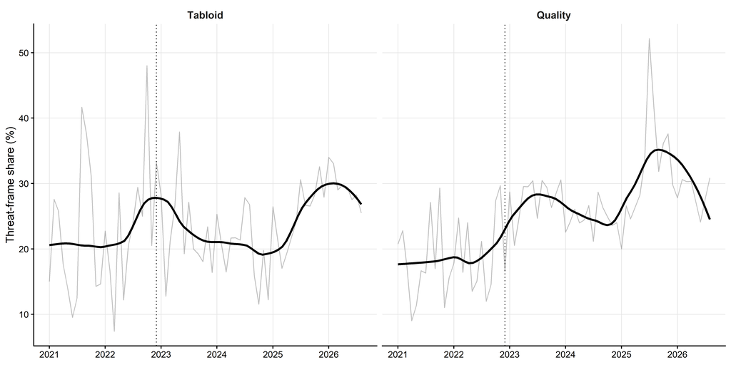

Figure 7: Monthly threat-frame share, tabloid and quality outlets

**Note:** Share of web items from the named tabloid (24sata, Index.hr, Net.hr) and quality (Jutarnji list, Večernji list, Dnevnik.hr, N1, Telegram, Tportal) outlets that carry a threat frame. Thin lines: monthly values; thick lines: LOESS smooths. The dotted line marks December 2022.

Table 13 extends the comparison to all outlet types, estimating the trend-adjusted post-launch change in each type’s monthly threat and opportunity shares.

Table 13: Post-launch change in threat and opportunity shares by outlet type

| Type | Items | Threat coefficient | p (threat) | Opportunity coefficient | p (opportunity) |
| --- | --- | --- | --- | --- | --- |
| Tabloid | 6,488 | -3.99 | 0.253 | -9.81 | 0.017 |
| Quality | 16,421 | 3.90 | 0.147 | -3.41 | 0.320 |
| Regional | 3,271 | 3.88 | 0.541 | -0.05 | 0.991 |
| Public | 1,053 | 6.47 | 0.282 | -7.27 | 0.251 |
| Tech | 3,664 | 3.68 | 0.228 | 2.44 | 0.528 |
| Business | 6,538 | 3.46 | 0.200 | 0.81 | 0.823 |
| Other web | 74,122 | 2.05 | 0.240 | -3.80 | 0.168 |
| Non-web | 23,194 | -7.10 | 0.349 | -7.82 | 0.002 |

Note: For each outlet type: coefficient on a post-launch indicator in a regression of the monthly threat (or opportunity) share on the indicator and a linear trend, with Newey-West (HAC) standard errors. Pre- and post-launch means are in the descriptive table by outlet type.

Within outlet types, the monthly series are short and noisy, and none of the trend-adjusted threat coefficients is significant. The opportunity share falls significantly for tabloids and for non-web platforms. Together with the difference-in-differences, this points to a broad-based shift in coverage rather than one concentrated in a single segment of the market.

## 6.9 Mechanisms

We consider three channels through which the threat shift could arise.

**Wire copy.** If Croatian outlets imported the threat tilt by republishing international agency copy, near-identical headlines would appear in several outlets within a few days, and the share of such items would rise after the launch. We flag an item as a near-duplicate if its title shares at least 70% of its words (Jaccard similarity on words of four or more letters) with an item from another source within three days.

Table 14: Near-duplicate items before and after the launch

| Period | Items | Near-duplicates | Share (%) | Threat share, near-duplicates (%) | Threat share, other items (%) |
| --- | --- | --- | --- | --- | --- |
| Pre-launch | 15,920 | 4,141 | 26.0 | 12.8 | 17.7 |
| Post-launch | 114,779 | 25,398 | 22.1 | 20.4 | 25.0 |

Note: Near-duplicate: title-word Jaccard similarity of at least 0.7 with an item from a different source published within three days. Candidate pairs are restricted to items sharing one of their two rarest title words. Items with fewer than three title words are excluded.

The near-duplicate share falls from 26.0% before the launch to 22.1% after it, and near-duplicates carry *less* threat framing than other items in both periods. Copied material is therefore not the source of the threat shift; it is concentrated in original coverage.

**Editorial selection.** The difference-in-differences shows that the threat shift is not driven by tabloids: quality outlets moved further. Any editorial-selection explanation therefore has to operate across the market rather than in its most attention-driven segment.

**Reader demand.** The monitoring database records reader interactions (reactions, comments and shares) for web articles, which lets us test whether threat-framed articles attract more engagement. Table 15 regresses log interactions on the two frame indicators with outlet and year-month fixed effects, so the comparison is between articles from the same outlet in the same month.

Table 15: Reader interactions and framing, web articles

|  | (1) log(1 + interactions) | (2) log(interactions), interactions > 0 |
| --- | --- | --- |
| Threat frame | 0.099 | 0.025 |
|  | (0.024) | (0.028) |
| Opportunity frame | -0.060 | -0.092 |
|  | (0.021) | (0.019) |
| Observations | 110,827 | 41,688 |

Note: Web items with a recorded interaction count. Interactions: the monitoring vendor's total of reactions, comments and shares. Both columns include source (outlet) and year-month fixed effects; standard errors clustered by source in parentheses. Column 2 drops items with zero interactions, which may reflect missing measurement rather than no engagement.

Threat-framed articles receive about 10.4% more interactions than other articles from the same outlet and month (p = < 0.001), and opportunity-framed articles about 5.8% fewer (p = 0.005). The estimates are correlations, not causal effects of framing on engagement, and the vendor’s interaction measure is undocumented. They are, however, what the demand-side mechanism predicts, and they give editors a reason to supply threat framing that does not depend on outlet type.

## 6.10 Persistence

Figure 8 plots three-month moving averages of the two indices, and Table 16 tests whether each series trends after the launch.

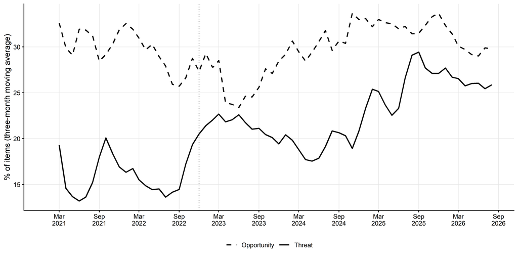

Figure 8: Threat and opportunity indices, three-month moving averages

**Note:** Right-aligned three-month moving averages of the monthly threat and opportunity shares. The dotted line marks December 2022.

Table 16: Post-launch trends in frame shares

| Series | Level at launch (%) | Slope (pp/month) | SE | p | Pattern |
| --- | --- | --- | --- | --- | --- |
| JOB_LOSS | 2.49 | -0.001 | 0.005 | 0.792 | No significant trend |
| JOB_CREATION | 4.23 | 0.004 | 0.012 | 0.712 | No significant trend |
| TRANSFORMATION | 4.80 | -0.000 | 0.015 | 0.995 | No significant trend |
| SKILLS | 5.60 | -0.019 | 0.010 | 0.074 | Falling |
| REGULATION | 4.61 | 0.037 | 0.016 | 0.025 | Rising |
| PRODUCTIVITY | 21.95 | 0.144 | 0.057 | 0.015 | Rising |
| INEQUALITY | 2.15 | 0.008 | 0.007 | 0.245 | No significant trend |
| FEAR_RESISTANCE | 16.16 | 0.187 | 0.052 | < 0.001 | Rising |
| Threat index | 19.02 | 0.181 | 0.048 | < 0.001 | Rising |
| Opportunity index | 26.74 | 0.137 | 0.058 | 0.022 | Rising |
| Gap (threat - opportunity) | -7.72 | 0.044 | 0.070 | 0.529 | No significant trend |

Note: Sample: post-launch months only (December 2022 onward). Regression of each monthly share on months since the launch; the intercept is the fitted share in December 2022. Newey-West (HAC) standard errors. Pattern uses the 10% level.

Nothing that rose after the launch fades. Fear and resistance, productivity and regulation keep rising, skills keeps drifting down, and both composite indices trend upward, the threat index faster than the opportunity index, although the difference between their slopes is not significant. The post-launch shift in coverage is not a novelty spike but a change of direction that continued for almost four years.

# 7 Robustness

## 7.1 Event Windows

The full-sample estimates compare almost four post-launch years with less than two pre-launch years, and a linear trend fitted to the whole period absorbs gradual change. Table 17 re-estimates the trend-adjusted change in the threat index in symmetric windows around the launch.

Table 17: Threat-index change in symmetric windows around the launch

| Window | Post coefficient (pp) | SE | p |
| --- | --- | --- | --- |
| ±6 months | -1.62 | 3.40 | 0.645 |
| ±9 months | 1.83 | 3.75 | 0.632 |
| ±12 months | 4.45 | 3.30 | 0.193 |
| ±18 months | 5.89 | 3.04 | 0.062 |
| ±24 months | 5.75 | 2.35 | 0.019 |
| ±36 months | 1.44 | 2.32 | 0.536 |

Note: Dependent variable: monthly share of items carrying a threat frame (percentage points). Each row uses the months within the stated distance of December 2022. Regression on a post-launch indicator and a linear trend; Newey-West (HAC) standard errors.

In the narrowest windows the estimate is imprecise, because six or nine months on each side leave too few monthly observations to separate a level change from a trend. From 12 months onward the coefficient is positive, at four to six percentage points within 12 to 24 months of the launch, and significant at the 10% level at 18 months and at the 5% level at 24 months. In the ±36-month window, which contains the whole pre-launch period and therefore the same comparison as the full sample, the coefficient shrinks again as the trend absorbs the rise.

## 7.2 Sample, Dictionary and Outlet Perturbations

Table 18 reports the trend-adjusted change in the threat index under alternative samples and dictionaries. None of these perturbations changes the conclusion drawn from the full sample: restricting the sample to web items, dropping January 2023 (the month of euro adoption and Schengen entry), or dropping any single tabloid leaves the estimate small and imprecise, so over the full period the shift is gradual rather than a level break at the launch. Dropping the fear-and-resistance dictionary, whose terms are the most generic, leaves a threat index built from job loss and inequality alone, with a coefficient of 0.9 points (p = 0.10).

Table 18: Threat-index change under alternative samples and dictionaries

| Specification | Post coefficient (pp) | SE | p |
| --- | --- | --- | --- |
| Full sample (reference) | 1.19 | 1.95 | 0.545 |
| Web items only | 2.22 | 1.78 | 0.216 |
| Excluding January 2023 | 0.67 | 1.95 | 0.731 |
| Threat without fear/resistance | 0.92 | 0.55 | 0.098 |
| Excluding 24sata | 1.20 | 1.93 | 0.539 |
| Excluding Index.hr | 1.31 | 1.97 | 0.508 |
| Excluding Net.hr | 1.22 | 1.93 | 0.531 |

Note: Dependent variable: monthly share of items carrying a threat frame (percentage points), full sample period. Regression on a post-launch indicator and a linear trend; Newey-West (HAC) standard errors. 'Threat without fear/resistance' counts only the job-loss and inequality frames.

## 7.3 Placebo Test

If the change in December 2022 were a seasonal artefact, a comparable change should appear at other year-ends. We apply the level-shift specification to December 2021, using only months before the actual launch.

Table 19: Placebo launch date: December 2021

| Term | Estimate | SE | p |
| --- | --- | --- | --- |
| Intercept | 770.01 | 54.55 | < 0.001 |
| Placebo post (December 2021 onward) | -36.32 | 84.95 | 0.674 |
| Time trend | -2.33 | 6.67 | 0.731 |

Note: Dependent variable: items per month. Sample: January 2021 to November 2022. Newey-West (HAC) standard errors.

The placebo coefficient is -36.3 items (p = 0.67). There is no change at the placebo date.

## 7.4 Count Models

Table 20 reports the quasi-Poisson volume model with a linear trend, and Appendix C a negative binomial alternative. Both give the same reading as Table 6: large post-launch volume relative to the pre-launch level, most of which a single linear trend over the whole period absorbs.

Table 20: Quasi-Poisson model of monthly item volume

| Term | Estimate | SE | p | IRR |
| --- | --- | --- | --- | --- |
| (Intercept) | 6.196 | 0.081 | < 0.001 | 490.70 |
| post | 0.085 | 0.118 | 0.476 | 1.09 |
| t | 0.033 | 0.002 | < 0.001 | 1.03 |
| Dispersion parameter | 95.64 |  |  |  |

Note: Dependent variable: items per month. Quasi-Poisson regression on a post-launch indicator and a linear trend (t, months since January 2021). IRR = exp(coefficient). A dispersion parameter well above one indicates overdispersion relative to a Poisson model.

# 8 Discussion

Croatian-language coverage of AI and the labour market changed direction at the ChatGPT launch. Volume did not jump in December 2022; its trend did, by 92.8 items per month, and the first data-driven break falls in Feb 2023. A second acceleration followed in Jun 2024. By 2026 coverage ran at 4,616 items a month, against 725 before the launch.

The tone shifted with the volume. The threat share rose from 16.5% to 23.0% while the opportunity share stayed flat; fear-and-resistance framing kept growing for more than three years; and skills and reskilling framing fell and did not recover. Opportunity framing remains more common than threat framing in levels, so the information environment is not dominated by threat. What changed is the balance: generative AI brought a rise in threat framing and a decline in adjustment framing, not a symmetric increase in both.

Two results qualify the conceptual framework. First, the shift was gradual. A model that allows only a level change at the launch and a common trend finds little, while windows of 18 to 24 months around the launch and the event-study coefficients show a clear rise. Second, quality outlets, not tabloids, moved furthest. The tabloidisation prediction fails; the reader-engagement result suggests one explanation. Threat framing attracts more interactions across outlets, not only in tabloids, so the incentive to supply it is market-wide. Why quality outlets responded most, for instance because they publish more AI and economy stories in which to use it, is a question for further work.

The evidence has limits. The dictionaries are not validated against human coding. The corpus measures supply, not exposure or belief. The long post-period contains later events, including GPT-4 and the EU AI Act, that our design does not separate from the launch. And the interaction measure behind the demand-side result is a vendor metric of undocumented construction.

# 9 Conclusion

ChatGPT’s release set Croatian coverage of AI and the labour market on a new path. Coverage accelerated rather than jumped; threat framing, led by fear and resistance, rose and kept rising for almost four years; and skills framing fell. The shift was broad-based: quality outlets moved further than tabloids, and threat-framed articles attract more reader engagement across the market.

Two extensions follow. The first is comparative: applying the same design to other small European language markets would show whether this pattern is specific to Croatia. The second links supply to demand: combining coverage with survey data on workers’ expectations would show whether the shift in framing moves beliefs about job security and the willingness to retrain.

# 10 Appendix

## 10.1 A. Dictionaries and Validation

Table 21: Frame dictionaries

[output not shown]

Note: An item carries a frame if any keyword occurs in its lower-cased title or text. Threat-leaning frames first, opportunity-leaning frames second, the other two last. Dictionaries are defined in config.yml.

**Validation.** The chunk below reads `data/validation/human_coded.csv` if present (columns `article_id`, `frame`, `human_label`, `machine_label`) and reports agreement, precision, recall and Cohen’s κ.

Table 22: Agreement with human coding

[output not shown]

## 10.2 B. Event-Study Coefficients

Table 23: Event-study coefficients at selected bins

| Frame | Bin starts | Estimate | SE | p |
| --- | --- | --- | --- | --- |
| JOB_LOSS | Dec 2021 | -2.80 | 0.77 | < 0.001 |
| JOB_LOSS | Jun 2022 | -2.33 | 0.77 | 0.004 |
| JOB_LOSS | Dec 2022 | -0.54 | 0.78 | 0.491 |
| JOB_LOSS | Jun 2023 | -0.92 | 0.77 | 0.239 |
| JOB_LOSS | Dec 2023 | -0.71 | 0.80 | 0.375 |
| JOB_LOSS | Dec 2024 | -0.86 | 0.76 | 0.262 |
| JOB_LOSS | Dec 2025 | -1.11 | 0.76 | 0.148 |
| JOB_LOSS | Jun 2026 | -1.16 | 0.77 | 0.136 |
| JOB_CREATION | Dec 2021 | 1.63 | 0.51 | 0.002 |
| JOB_CREATION | Jun 2022 | -0.32 | 0.32 | 0.321 |
| JOB_CREATION | Dec 2022 | -0.28 | 0.54 | 0.608 |
| JOB_CREATION | Jun 2023 | 0.85 | 0.25 | 0.001 |
| JOB_CREATION | Dec 2023 | 1.00 | 0.35 | 0.006 |
| JOB_CREATION | Dec 2024 | 0.45 | 0.20 | 0.032 |
| JOB_CREATION | Dec 2025 | 0.35 | 0.43 | 0.411 |
| JOB_CREATION | Jun 2026 | 0.01 | 0.16 | 0.941 |
| TRANSFORMATION | Dec 2021 | 2.82 | 0.63 | < 0.001 |
| TRANSFORMATION | Jun 2022 | 1.15 | 0.51 | 0.030 |
| TRANSFORMATION | Dec 2022 | 0.90 | 0.58 | 0.128 |
| TRANSFORMATION | Jun 2023 | 0.51 | 0.53 | 0.344 |
| TRANSFORMATION | Dec 2023 | 1.41 | 0.31 | < 0.001 |
| TRANSFORMATION | Dec 2024 | 1.17 | 0.30 | < 0.001 |
| TRANSFORMATION | Dec 2025 | 1.20 | 0.36 | 0.002 |
| TRANSFORMATION | Jun 2026 | 0.65 | 0.33 | 0.056 |
| SKILLS | Dec 2021 | -1.46 | 0.87 | 0.101 |
| SKILLS | Jun 2022 | -0.70 | 1.11 | 0.528 |
| SKILLS | Dec 2022 | -4.06 | 0.98 | < 0.001 |
| SKILLS | Jun 2023 | -3.01 | 0.88 | 0.001 |
| SKILLS | Dec 2023 | -3.86 | 0.89 | < 0.001 |
| SKILLS | Dec 2024 | -4.12 | 1.00 | < 0.001 |
| SKILLS | Dec 2025 | -3.99 | 1.03 | < 0.001 |
| SKILLS | Jun 2026 | -3.90 | 0.88 | < 0.001 |
| REGULATION | Dec 2021 | 1.27 | 2.11 | 0.549 |
| REGULATION | Jun 2022 | -0.43 | 0.36 | 0.243 |
| REGULATION | Dec 2022 | 1.07 | 0.52 | 0.046 |
| REGULATION | Jun 2023 | 3.04 | 1.04 | 0.006 |
| REGULATION | Dec 2023 | 1.97 | 0.72 | 0.009 |
| REGULATION | Dec 2024 | 4.73 | 0.37 | < 0.001 |
| REGULATION | Dec 2025 | 1.88 | 0.66 | 0.007 |
| REGULATION | Jun 2026 | 2.20 | 0.87 | 0.014 |
| PRODUCTIVITY | Dec 2021 | -0.33 | 0.82 | 0.689 |
| PRODUCTIVITY | Jun 2022 | -3.45 | 1.13 | 0.004 |
| PRODUCTIVITY | Dec 2022 | -1.25 | 1.55 | 0.424 |
| PRODUCTIVITY | Jun 2023 | -4.65 | 0.65 | < 0.001 |
| PRODUCTIVITY | Dec 2023 | 1.07 | 0.96 | 0.273 |
| PRODUCTIVITY | Dec 2024 | 3.43 | 0.64 | < 0.001 |
| PRODUCTIVITY | Dec 2025 | 2.21 | 1.36 | 0.111 |
| PRODUCTIVITY | Jun 2026 | 0.93 | 1.17 | 0.431 |
| INEQUALITY | Dec 2021 | 1.40 | 0.64 | 0.033 |
| INEQUALITY | Jun 2022 | -0.05 | 0.50 | 0.921 |
| INEQUALITY | Dec 2022 | 0.77 | 0.51 | 0.139 |
| INEQUALITY | Jun 2023 | 1.28 | 0.54 | 0.023 |
| INEQUALITY | Dec 2023 | 1.20 | 0.44 | 0.009 |
| INEQUALITY | Dec 2024 | 0.98 | 0.38 | 0.013 |
| INEQUALITY | Dec 2025 | 0.90 | 0.43 | 0.041 |
| INEQUALITY | Jun 2026 | 1.11 | 0.38 | 0.006 |
| FEAR_RESISTANCE | Dec 2021 | -0.76 | 1.38 | 0.587 |
| FEAR_RESISTANCE | Jun 2022 | -3.14 | 1.52 | 0.045 |
| FEAR_RESISTANCE | Dec 2022 | 3.33 | 2.23 | 0.143 |
| FEAR_RESISTANCE | Jun 2023 | 3.05 | 1.42 | 0.037 |
| FEAR_RESISTANCE | Dec 2023 | 1.42 | 1.55 | 0.364 |
| FEAR_RESISTANCE | Dec 2024 | 7.43 | 1.59 | < 0.001 |
| FEAR_RESISTANCE | Dec 2025 | 8.80 | 1.43 | < 0.001 |
| FEAR_RESISTANCE | Jun 2026 | 8.04 | 1.45 | < 0.001 |

Note: Dependent variable: monthly frame share (percentage points). Coefficients on three-month event-time bins; reference bin September-November 2022. Newey-West (HAC) standard errors. These coefficients are plotted in the event-study figure.

## 10.3 C. Alternative Specifications

Table 24: Negative binomial model of monthly item volume

| Term | Estimate | SE | p | IRR |
| --- | --- | --- | --- | --- |
| (Intercept) | 6.283 | 0.060 | < 0.001 | 535.20 |
| post | 0.137 | 0.111 | 0.217 | 1.15 |
| t | 0.030 | 0.003 | < 0.001 | 1.03 |
| Theta | 16.40 |  |  |  |

Note: Dependent variable: items per month. Regression on a post-launch indicator and a linear trend. Smaller theta means more overdispersion.

Table 25: Item-level linear probability model for the threat indicator

| Term | Estimate | SE | p |
| --- | --- | --- | --- |
| Post-launch | 0.0174 | 0.0097 | 0.071 |
| Linear trend (months) | 0.0009 | 0.0002 | < 0.001 |

Note: Dependent variable: 1 if the item carries a threat frame. Source and month-of-year fixed effects (year-month fixed effects would absorb the post-launch indicator). Standard errors clustered by source. N = 131,906.

## 10.4 D. Sample Excerpts by Frame

Table 26: Sample excerpts by frame

| Frame | Outlet | Date | Excerpt |
| --- | --- | --- | --- |
| JOB_LOSS | bloombergadria.com | 2025-12-12 | Ljudi gube posao - investitori aplaudiraju Val masovnih otpuštanja ove godine zahvatio je cijelo američko gospodarstvo. Link copied Copy link Popis američkih tvrtki koje su ove godine otpustile sve je |
| JOB_LOSS | index.hr | 2025-12-04 | Trenutno se nalazimo u "eri vječnih otkaza". Znate li što je to? NOVI trend Trenutno se nalazimo u "eri vječnih otkaza". Znate li što je to? Index Magazin Screenshot: TikTok Tekst se nastavlja ispod o |
| JOB_LOSS | geek.hr | 2024-01-23 | Zabrinjavajući trendovi u tehnologiji koji potiču masovna otpuštanja u Googleu i Amazonu Tehnološki sektor, nekad poznat po sigurnosti posla, suočava se s mračnom budućnošću nakon velikih otpuštanja u |
| JOB_CREATION | poslovnojutro.com | 2025-01-09 | Deficitarna zanimanja u Srbiji: Koji su kadrovi najtraženiji i zašto? - Tema - Srbija U poslednjih nekoliko godina, Srbija se suočava sa ozbiljnim problemom nedostatka stručnog kadra u određenim oblas |
| JOB_CREATION | zg-magazin.com.hr | 2021-07-30 | Strah od nezaposlenosti zbog primjene automatizacije Strojevi će zamijeniti ljude na mnogim poslovima. Strah je pojačan i najavama da je neminovno uskoro susretanje s robotima u životnom okruženju, s |
| JOB_CREATION | novimilenij.eu | 2024-02-27 | Huawei u Barceloni predstavio 5.5G koji komercijalno kreće ove godine i otvara nove mogućnosti razvoja mobilnih komunikacija Huawei je na najvećem godišnjem sajmu industrije mobilnih komunikacija, MWC |
| TRANSFORMATION | poslovne.com | 2021-08-19 | 9 najefikasnijih transformacija poslovanja Međutim, postavlja se pitanje da li znamo šta je transformacija poslovanja? Čemu ona služi? Zašto je toliko važna? Kada nam je potrebna? Koji sve oblici post |
| TRANSFORMATION | geek.hr | 2023-11-23 | Brza prilagodba tržištu je važnija nego ikada prije, no kako je ostvariti? Poslovno tržište danas se izuzetno brzo mijenja - gotovo na svakodnevnoj razini. Digitalizacija raznih sustava omogućava da s |
| TRANSFORMATION | croativ.net | 2025-10-22 | AI NAŠA SVAGDAŠNJA Zanimljiv mudroslovni duel s digitalnim bogom Mario Škorin u razgovoru s AI – Umjetnom inteligencijom o ‘zadnjim’ ljudskim pitanjima, stremljenjima i nadom. Uz kontekst stvaranja, š |
| SKILLS | geek.hr | 2025-07-15 | Kako programirati u Pythonu? Donosimo 7 osnovnih naredbi Kako programirati u Pythonu? Otkrijte 7 osnovnih naredbi i savjete koji će vam pomoći da započnete jednostavno i učinkovito s učenjem Pythona. |
| SKILLS | geek.hr | 2024-08-28 | Recenzija: Koji je najbolji laptop za programiranje u 2024. godini? Tražite najbolji laptop za programiranje u 2024. godini? Na pravom ste mjestu! Kao programer, vaš laptop je vaš najvjerniji suputnik |
| SKILLS | indeks.hr | 2025-03-07 | Što je Python? 8 ključnih pojmova za početnike Što je Python? Otkrij osnovne pojmove i nauči kako koristiti Python za programiranje, analizu podataka i automatizaciju zadataka. indeks.hr Što je Python |
| REGULATION | vecernji.hr | 2025-05-12 | Predstojnik Vladina Ureda za socijalno partnerstvo: 'Premijeru sam jasno rekao da pritiske neću trpjeti' Ured nije zamišljen da bude na jednoj strani, već kao mjesto susreta svih strana – svojevrstan |
| REGULATION | glas-slavonije.hr | 2021-04-30 | Odgovorni smo za ono što radimo, ali i za ono što i kako praznujemo PRAZNIK RADA U KORONI (I) PRAZNIK RADA U KORONI (I) Odgovorni smo za ono što radimo, ali i za ono što i kako praznujemo Objavljeno p |
| REGULATION | radnickaprava.org | 2023-03-24 | Iz radničke štampe: godina 01, broj 01 Radnička prava su portal koji donosi pregled vijesti, tekstova i video materijala s temom radničkih prava i radničkih borbi. Iz radničke štampe: godina 01, broj |
| PRODUCTIVITY | zakon.hr | 2024-03-25 | o energetskoj učinkovitosti Zakon o energetskoj učinkovitosti Zakon o energetskoj učinkovitosti Zakon o energetskoj učinkovitosti pročišćeni tekst zakona Baza je ažurirana 25.03.2024. zaključno sa NN |
| PRODUCTIVITY | zakon.hr | 2026-01-01 | o energetskoj učinkovitosti Zakon o energetskoj učinkovitosti Zakon o energetskoj učinkovitosti Zakon o energetskoj učinkovitosti NN 155/25 Predmet Zakona Članak 1. Ovim Zakonom uređuju se mjere polit |
| PRODUCTIVITY | zakon.hr | 2023-06-19 | o energetskoj učinkovitosti Zakon o energetskoj učinkovitosti Zakon o energetskoj učinkovitosti Upišite Vaš e-mail za obavijesti o promjeni ovog zakona: I. OPĆE ODREDBE Predmet Zakona Članak 1. (NN 11 |
| INEQUALITY | bug.hr | 2022-07-14 | Algoritamska pristranost prati društvenu nejednakost Rezultati istraživanja pokazuju da su društvene razine nejednakosti očite u algoritmima internetskog pretraživanja i da izloženost algoritamskom re |
| INEQUALITY | poslovni.hr | 2025-10-02 | Indija nakon građanstva: Ogledalo budućnosti u vremenu raspada modernog društva Indija je nekad bila percipirana kao “zemlja u razvoju” – zemlja kontrasta, vjerske raznolikosti, postkolonijalnog demok |
| INEQUALITY | novine.hr | 2022-07-14 | Algoritamska pristranost prati društvenu nejednakost Umjetna inteligencija može promijeniti našu percepciju i djelovanje, pokazuje rad objavljen u časopisu Proceedings of the National Academy of Scien |
| FEAR_RESISTANCE | zastita.info | 2026-03-03 | Korištenje umjetne inteligencije za rješavanje složenosti rizika od katastrofa Umjetna inteligencija otvara snažne nove mogućnosti za smanjenje rizika od katastrofa. Ali pravi napredak neće doći samo |
| FEAR_RESISTANCE | hop.com.hr | 2025-03-24 | Ekskluzivna studija: 5G Opasnost - zračenje unutar tijela 5G MREŽA JE DIO PROGRAMA ZAPOVIJEDANJA, KONTROLE, NADZORA I UMJETNE INTELIGENCIJE (AI) G opasnost: 13 razloga zašto će 5G bežična tehnologija |
| FEAR_RESISTANCE | indeks.hr | 2023-06-05 | Što je apokalipsa? 6 činjenica za koje možda niste znali Izraz “apokalipsa” često asocira na slike katastrofalnih događaja, smaka svijeta ili velikog raspleta civilizacije. Izveden iz grčke riječi “ap |

Note: Three web items per frame with the most dictionary matches; first 200 characters of the text.

## 10.5 E. Outlet-Level Statistics

Table 27: Web sources with at least 50 items

| Source | Type | Total | Pre | Post | Threat (%) | Opportunity (%) |
| --- | --- | --- | --- | --- | --- | --- |
| ictbusiness.info | Other web | 4414 | 483 | 3931 | 17.1 | 40.6 |
| tportal.hr | Quality | 4236 | 505 | 3731 | 28.0 | 29.2 |
| dnevnik.hr | Quality | 4068 | 358 | 3710 | 33.3 | 26.4 |
| poslovni.hr | Business | 3840 | 443 | 3397 | 27.4 | 44.4 |
| jutarnji.hr | Quality | 3188 | 774 | 2414 | 23.9 | 29.8 |
| index.hr | Tabloid | 2992 | 323 | 2669 | 29.5 | 19.7 |
| vecernji.hr | Quality | 2976 | 529 | 2447 | 22.6 | 26.5 |
| bug.hr | Tech | 2919 | 383 | 2536 | 19.6 | 30.9 |
| lidermedia.hr | Business | 2358 | 218 | 2140 | 24.5 | 44.4 |
| 24sata.hr | Tabloid | 2086 | 289 | 1797 | 21.2 | 27.5 |
| novilist.hr | Regional | 1853 | 228 | 1625 | 22.8 | 25.4 |
| bloombergadria.com | Other web | 1770 | 26 | 1744 | 42.1 | 30.9 |
| crovijesti.com | Other web | 1695 | 0 | 1695 | 38.2 | 26.0 |
| seebiz.eu | Other web | 1587 | 167 | 1420 | 24.8 | 32.1 |
| slobodnadalmacija.hr | Regional | 1418 | 308 | 1110 | 23.2 | 20.9 |
| net.hr | Tabloid | 1410 | 34 | 1376 | 22.2 | 21.1 |
| glas-slavonije.hr | Other web | 1238 | 155 | 1083 | 29.0 | 35.9 |
| glasistre.hr | Other web | 1195 | 245 | 950 | 22.2 | 24.3 |
| telegram.hr | Quality | 1148 | 153 | 995 | 28.9 | 30.3 |
| financije.hr | Other web | 1122 | 0 | 1122 | 24.8 | 33.9 |
| hrt.hr | Public | 1053 | 110 | 943 | 20.9 | 21.8 |
| novine.hr | Other web | 980 | 105 | 875 | 16.3 | 18.9 |
| n1info.hr | Quality | 805 | 10 | 795 | 27.1 | 22.4 |
| dalmatinskiportal.hr | Other web | 801 | 88 | 713 | 13.0 | 30.7 |
| infokiosk.net | Other web | 749 | 4 | 745 | 18.3 | 26.0 |
| netokracija.com | Tech | 745 | 223 | 522 | 17.4 | 30.6 |
| nacional.hr | Other web | 742 | 216 | 526 | 34.5 | 27.6 |
| vidi.hr | Other web | 742 | 160 | 582 | 11.9 | 31.5 |
| srednja.hr | Other web | 682 | 88 | 594 | 13.9 | 16.3 |
| pcekspert.com | Other web | 639 | 38 | 601 | 23.3 | 42.3 |

[output cut: 266 more lines]

Note: Web sources (domains) with at least 50 corpus items. Pre and post split at December 1, 2022. Type as in the outlet classification; Other web for unlisted domains.

## 10.6 F. Replication

The corpus (`data/raw/ai_labour_corpus_2021_2026.rds`) is produced by `R/01_extract_corpus.R` from the merged Determ database, which is proprietary and not distributed. This document renders from `R/04_paper1_chatgpt_natural_experiment.qmd`. Frame dictionaries, the SQL and regular-expression filters, the outlet list, and the event dates are defined in `config.yml`; shared functions, including the outlet classification and the wild-cluster bootstrap, are in `R/00_helpers.R`.

## References

Acemoglu, Daron, and Pascual Restrepo. 2018. “The Race Between Man and Machine: Implications of Technology for Growth, Factor Shares, and Employment.” *American Economic Review* 108 (6): 1488–542.

Autor, David H. 2015. “Why Are There Still so Many Jobs? The History and Future of Workplace Automation.” *Journal of Economic Perspectives* 29 (3): 3–30.

Autor, David H. 2022. *The Labor Market Impacts of Technological Change: From Unbridled Enthusiasm to Qualified Optimism to Vast Uncertainty*. Working Paper No. 30074. National Bureau of Economic Research. https://doi.org/10.3386/w30074.

Bernal, James Lopez, Steven Cummins, and Antonio Gasparrini. 2017. “Interrupted Time Series Regression for the Evaluation of Public Health Interventions: A Tutorial.” *International Journal of Epidemiology* 46 (1): 348–55. https://doi.org/10.1093/ije/dyw098.

Bessen, James E. 2019. “Automation and Jobs: When Technology Boosts Employment.” *Economic Policy* 34 (100): 589–626.

Brynjolfsson, Erik, Danielle Li, and Lindsey R. Raymond. 2023. “Generative AI at Work.” *NBER Working Paper*, no. 31161.

Cameron, A. Colin, Jonah B. Gelbach, and Douglas L. Miller. 2008. “Bootstrap-Based Improvements for Inference with Clustered Errors.” *Review of Economics and Statistics* 90 (3): 414–27.

Chaisemartin, Clément de, and Xavier D’Haultfœuille. 2020. “Two-Way Fixed Effects Estimators with Heterogeneous Treatment Effects.” *American Economic Review* 110 (9): 2964–96.

Chuan, Ching-Hua, Wan-Hsiu Sunny Tsai, and Su Yeon Cho. 2019. “Framing Artificial Intelligence in American Newspapers.” *Proceedings of the 2019 AAAI/ACM Conference on AI, Ethics, and Society*, 339–44. https://doi.org/10.1145/3306618.3314285.

Eloundou, Tyna, Sam Manning, Pamela Mishkin, and Daniel Rock. 2023. “GPTs are GPTs: An Early Look at the Labor Market Impact Potential of Large Language Models.” *arXiv Preprint arXiv:2303.10130*.

Entman, Robert M. 1993. “Framing: Toward Clarification of a Fractured Paradigm.” *Journal of Communication* 43 (4): 51–58. https://doi.org/10.1111/j.1460-2466.1993.tb01304.x.

Esser, Frank. 1999. “‘Tabloidization’ of News: A Comparative Analysis of Anglo-American and German Press Journalism.” *European Journal of Communication* 14 (3): 291–324. https://doi.org/10.1177/0267323199014003001.

Fast, Ethan, and Eric Horvitz. 2017. “Long-Term Trends in the Public Perception of Artificial Intelligence.” *Proceedings of the AAAI Conference on Artificial Intelligence* 31. https://doi.org/10.1609/aaai.v31i1.10635.

Felten, Edward W., Manav Raj, and Robert Seamans. 2021. “Occupational, Industry, and Geographic Exposure to Artificial Intelligence: A Novel Dataset and Its Potential Uses.” *Strategic Management Journal* 42 (12): 2195–217.

Gentzkow, Matthew, and Jesse M. Shapiro. 2010. “What Drives Media Slant? Evidence from U.S. Daily Newspapers.” *Econometrica* 78 (1): 35–71.

Goodman-Bacon, Andrew. 2021. “Difference-in-Differences with Variation in Treatment Timing.” *Journal of Econometrics* 225 (2): 254–77.

MacKinnon, James G., and Matthew D. Webb. 2017. “Wild Bootstrap Inference for Wildly Different Cluster Sizes.” *Journal of Applied Econometrics* 32 (2): 233–54.

Mullainathan, Sendhil, and Andrei Shleifer. 2005. “The Market for News.” *American Economic Review* 95 (4): 1031–53.

Net.hr. 2021. *Velika Vijest Na Medijskoj Sceni: RTL Hrvatska Preuzima Portal Net.hr Od Telegram Media Grupe*. [Https://net.hr/danas/vijesti/velika-vijest-na-medijskoj-sceni-rtl-hrvatska-preuzima-portal-net-hr-od-telegram-media-grupe-e0eab03a-b1c3-11eb-811c-0242ac130060](https://net.hr/danas/vijesti/velika-vijest-na-medijskoj-sceni-rtl-hrvatska-preuzima-portal-net-hr-od-telegram-media-grupe-e0eab03a-b1c3-11eb-811c-0242ac130060).

Nguyen, Dennis, and Erik Hekman. 2024. “The News Framing of Artificial Intelligence: A Critical Exploration of How Media Discourses Make Sense of Automation.” *AI & Society* 39 (2): 437–51. https://doi.org/10.1007/s00146-022-01511-1.

Ouchchy, Leila, Allen Coin, and Veljko Dubljević. 2020. “AI in the Headlines: The Portrayal of the Ethical Issues of Artificial Intelligence in the Media.” *AI & Society* 35 (4): 927–36. https://doi.org/10.1007/s00146-020-00965-5.

Peruško, Zrinjka. 2024. “Croatia.” In *Reuters Institute Digital News Report 2024*, edited by Nic Newman, Richard Fletcher, Craig T. Robertson, Amy Ross Arguedas, and Rasmus Kleis Nielsen. Reuters Institute for the Study of Journalism. https://reutersinstitute.politics.ox.ac.uk/digital-news-report/2024/croatia.

Robertson, Claire E., Nicolas Pröllochs, Kaoru Schwarzenegger, Philip Pärnamets, Jay J. Van Bavel, and Stefan Feuerriegel. 2023. “Negativity Drives Online News Consumption.” *Nature Human Behaviour* 7 (5): 812–22. https://doi.org/10.1038/s41562-023-01538-4.

Roe, Jasper, and Mike Perkins. 2023. “‘What They’re Not Telling You about ChatGPT’: Exploring the Discourse of AI in UK News Media Headlines.” *Humanities and Social Sciences Communications* 10 (1). https://doi.org/10.1057/s41599-023-02282-w.

Scheufele, Dietram A. 1999. “Framing as a Theory of Media Effects.” *Journal of Communication* 49 (1): 103–22. https://doi.org/10.1111/j.1460-2466.1999.tb02784.x.

Semetko, Holli A., and Patti M. Valkenburg. 2000. “Framing European Politics: A Content Analysis of Press and Television News.” *Journal of Communication* 50 (2): 93–109. https://doi.org/10.1111/j.1460-2466.2000.tb02843.x.

Soroka, Stuart, Patrick Fournier, and Lilach Nir. 2019. “Cross-National Evidence of a Negativity Bias in Psychophysiological Reactions to News.” *Proceedings of the National Academy of Sciences* 116 (38): 18888–92. https://doi.org/10.1073/pnas.1908369116.

Soroka, Stuart, and Stephen McAdams. 2015. “News, Politics, and Negativity.” *Political Communication* 32 (1): 1–22. https://doi.org/10.1080/10584609.2014.881942.

Vreese, Claes H. de. 2005. “News Framing: Theory and Typology.” *Information Design Journal* 13 (1): 51–62. https://doi.org/10.1075/idjdd.13.1.06vre.